# Day 7 Activity: Data Cleaning Challenge

Student Name

2025-09-22

# 🔍 In-Class Activity: The Messy Sales Dataset

**Estimated Time:** 40 minutes

**Goal:** In this activity, you will act as a junior data analyst tasked with cleaning and preparing a new sales dataset. This dataset is “fresh off the press” and contains common data issues like inconsistent date formats, messy text, and missing values.

Your mission is to use the skills you learned today to get the data into a clean, tidy format suitable for analysis.

## Setup

First, let’s load the necessary packages and create our messy dataset.

```r
# Load the required packages
library(tidyverse)
library(lubridate)
library(stringr)
library(naniar)

# Create the messy dataset
sales_data <- tibble(
  order_id = c("ORD-20230115", "ORD-20230220", "ORD-20230325", "ORD-20240410", "ORD-20230505", "ORD-20230630", "ORD-20230712", "ORD-20220818", "ORD-20230920", "ORD-20231105"),
  order_date_str = c("Jan 15, 2023", "20/02/2023", "2023-03-25", "April 10 2024", "05-May-2023", "2023-06-30", "July 12, 2023", "18-Aug-2022", "Sep 20, 2023", "Nov 5, 2023"),
  shipping_time_str = c("10:30 AM", "14:05 PM", "12:00 PM", "9:15 AM", "11:45 AM", NA, "13:30 PM", "10:00 AM", "15:30 PM", "8:45 AM"),
  customer_info = c("John.D-New", "Jane_S_Old", "Peter_J-New", "Maria.L-New", "Mike_A_Old", "Sarah.W-New", "Sam.T_Old", "Emily_R_New", "David_K_New", "Lisa.M-Old"),
  customer_segment = c("Tier 1", "Tier 2", "Tier 1", "Tier 1", "Tier 2", "Tier 1", "Tier 2", "Tier 1", "Tier 1", "Tier 2"),
  product_revenue = c(150.75, 200.50, NA, 85.25, -50.00, 45.99, NA, 1250.00, 320.15, 89.99),
  feedback_status = c("Complete", "Pending", "N/A", "Complete", "Not provided", "Pending", "N/A", "Complete", "Pending", "Complete")
)

# Look at the data
sales_data
```

```
## # A tibble: 10 × 7
##    order_id     order_date_str shipping_time_str customer_info customer_segment
##    <chr>        <chr>          <chr>             <chr>         <chr>
##  1 ORD-20230115 Jan 15, 2023   10:30 AM          John.D-New    Tier 1
##  2 ORD-20230220 20/02/2023     14:05 PM          Jane_S_Old    Tier 2
##  3 ORD-20230325 2023-03-25     12:00 PM          Peter_J-New   Tier 1
##  4 ORD-20240410 April 10 2024  9:15 AM           Maria.L-New   Tier 1
##  5 ORD-20230505 05-May-2023    11:45 AM          Mike_A_Old    Tier 2
##  6 ORD-20230630 2023-06-30     <NA>              Sarah.W-New   Tier 1
##  7 ORD-20230712 July 12, 2023  13:30 PM          Sam.T_Old     Tier 2
##  8 ORD-20220818 18-Aug-2022    10:00 AM          Emily_R_New   Tier 1
##  9 ORD-20230920 Sep 20, 2023   15:30 PM          David_K_New   Tier 1
## 10 ORD-20231105 Nov 5, 2023    8:45 AM           Lisa.M-Old    Tier 2
## # ℹ 2 more variables: product_revenue <dbl>, feedback_status <chr>
```

## Part 1: Dates and Times (15 minutes)

Your first task is to fix the `order_date_str` and `shipping_time_str` columns.

### **Step 1: Fix the Order Date**

The `order_date_str` column contains dates in various formats. Convert this column to a proper `Date` object using `lubridate`.

**Hint:** You will need to use a combination of `mutate()` and `parse_date_time()`.

```r
# Your code goes here
sales_data <- sales_data %>%
  mutate(order_date = parse_date_time(order_date_str,
                                     orders = c("mdy", "dmy", "ymd", "Bdy")))
```

### **Step 2: Combine and Calculate**

The `shipping_time_str` is a character column. Convert it to a time format, then combine it with your clean `order_date` to create a single `POSIXct` timestamp. Finally, calculate the duration between the first and last order.

**Hint:** Use `paste0()` to combine the date and time strings before using `lubridate`’s parsing functions. Use `difftime()` for the calculation.

```r
# Your code goes here
sales_data <- sales_data %>%
  mutate(
    # Combine date and time strings
    datetime_str = paste0(as.Date(order_date), " ", shipping_time_str),
    # Parse to POSIXct
    order_timestamp = ymd_hm(datetime_str)
  ) %>%
  select(-datetime_str)  # Remove temporary column
# Calculate duration between first and last order
first_order <- min(sales_data$order_timestamp, na.rm = TRUE)
last_order <- max(sales_data$order_timestamp, na.rm = TRUE)
time_span <- difftime(last_order, first_order, units = "days")
cat("Duration between first and last order:", time_span)
```

```
## Duration between first and last order: 600.9688
```

## Part 2: String Manipulation (15 minutes)

The `customer_info` column is a mess! It contains the customer’s first name, last initial, and a status (either “New” or “Old”). You need to extract these pieces of information into separate columns.

### **Step 3: Extract Customer Status**

Extract the customer status (“New” or “Old”) into a new column called `customer_status`.

**Hint:** Use `str_extract()` with a simple pattern.

```r
# Your code goes here
sales_data <- sales_data %>%
  mutate(customer_status = str_extract(customer_info, "New|Old"))
```

### **Step 4: Clean Customer Names**

Clean the `customer_info` column to create a new column called `customer_name` that contains only the first name and last initial (e.g., “John D”). Remove any special characters (`.` or `_`).

**Hint:** Use `str_replace_all()` to remove the unwanted characters and `str_extract()` to pull out the first name and initial.

```r
# Your code goes here
sales_data <- sales_data %>%
  mutate(
    # Remove special characters and status, then extract name
    clean_info = str_replace_all(customer_info, "[._-](New|Old)", ""),
    clean_info = str_replace_all(clean_info, "[._]", " "),
    customer_name = str_trim(clean_info)
  ) %>%
  select(-clean_info)  # Remove temporary column
```

## Part 3: Handling Missing Values & Imputation (10 minutes)

Now, let’s address the missing data in our dataset. This is a crucial step for accurate analysis.

### **Step 5: Standardize and Impute**

The `feedback_status` column uses both “N/A” and “Not provided” as missing value indicators. First, standardize these by converting both to `NA`. Then, identify the missing value in `product_revenue` and **impute** it by replacing it with the mean of the other values **within its `customer_segment` group**.

**Hint:** Use `na_if()` to handle the string-based missing values. For imputation, you can use `group_by()` and `mutate()` together.

```r
# Your code goes here
sales_data_clean <- sales_data %>%
  mutate(
    # Standardize missing values in feedback_status
    feedback_status = na_if(feedback_status, "N/A"),
    feedback_status = na_if(feedback_status, "Not provided")
  ) %>%
  # Impute missing product_revenue with group mean
  group_by(customer_segment) %>%
  mutate(
    product_revenue = if_else(
      is.na(product_revenue),
      mean(product_revenue, na.rm = TRUE),
      product_revenue
    )
  ) %>%
  ungroup()
```

### **Step 6: Visualize the Clean Data**

Once you’ve standardized and imputed your data, visualize the missing values one last time with `vis_miss()` to confirm that all of your intended changes have been successful.

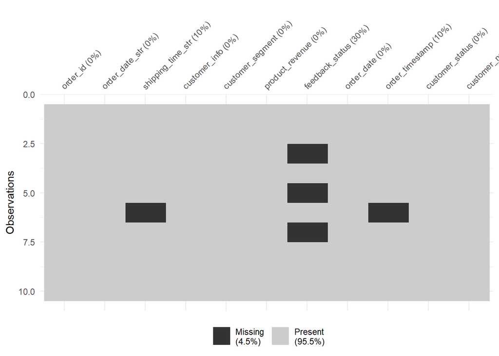

```r
# Your code goes here
vis_miss(sales_data_clean)
```

# 🏆 Challenge Activities

If you finish early or want extra practice, try these additional challenges that build on today’s topics!

## Challenge 1: Advanced Date Operations (10 minutes)

Create some additional time-based variables from your cleaned data.

### **Challenge 1A: Time Periods**

Calculate how many days have passed between each order and today’s date. Also, determine which day of the week each order was placed and which quarter of the year.

**Hint:** Use `today()`, `wday()`, and `quarter()` functions.

```r
# Your code goes here
# Note: Make sure you've completed Part 3 first to create sales_data_clean
# If not, replace sales_data_clean with your dataset name from Part 1-2
sales_data_clean %>%
  mutate(
    days_since_order = as.numeric(today() - order_date),
    day_of_week = wday(order_date, label = TRUE),
    quarter_year = quarter(order_date)
  ) %>%
  select(order_id, order_date, days_since_order, day_of_week, quarter_year)
```

```
## # A tibble: 10 × 5
##    order_id     order_date          days_since_order day_of_week quarter_year
##    <chr>        <dttm>                         <dbl> <ord>              <int>
##  1 ORD-20230115 2023-01-15 00:00:00      -1673720447 Sun                    1
##  2 ORD-20230220 2023-02-20 00:00:00      -1676830847 Mon                    1
##  3 ORD-20230325 2023-03-25 00:00:00      -1679682047 Sat                    1
##  4 ORD-20240410 2024-04-10 00:00:00      -1712686847 Wed                    2
##  5 ORD-20230505 2023-05-20 00:00:00      -1684520447 Sat                    2
##  6 ORD-20230630 2023-06-30 00:00:00      -1688062847 Fri                    2
##  7 ORD-20230712 2023-07-12 00:00:00      -1689099647 Wed                    3
##  8 ORD-20220818 2022-08-18 00:00:00      -1660760447 Thu                    3
##  9 ORD-20230920 2023-09-20 00:00:00      -1695147647 Wed                    3
## 10 ORD-20231105 2023-11-05 00:00:00      -1699122047 Sun                    4
```

### **Challenge 1B: Seasonal Analysis**

Create a new variable called `season` based on the order month: - Winter: Dec, Jan, Feb  
- Spring: Mar, Apr, May - Summer: Jun, Jul, Aug  
- Fall: Sep, Oct, Nov

**Hint:** Use `month()` and `case_when()` to create the seasonal categories.

```r
# Your code goes here
# Note: Make sure you've completed Part 3 first to create sales_data_clean
sales_data_clean %>%
  mutate(
    order_month = month(order_date),
    season = case_when(
      order_month %in% c(12, 1, 2) ~ "Winter",
      order_month %in% c(3, 4, 5) ~ "Spring",
      order_month %in% c(6, 7, 8) ~ "Summer",
      order_month %in% c(9, 10, 11) ~ "Fall"
    )
  ) %>%
  select(order_id, order_date, order_month, season)
```

```
## # A tibble: 10 × 4
##    order_id     order_date          order_month season
##    <chr>        <dttm>                    <dbl> <chr>
##  1 ORD-20230115 2023-01-15 00:00:00           1 Winter
##  2 ORD-20230220 2023-02-20 00:00:00           2 Winter
##  3 ORD-20230325 2023-03-25 00:00:00           3 Spring
##  4 ORD-20240410 2024-04-10 00:00:00           4 Spring
##  5 ORD-20230505 2023-05-20 00:00:00           5 Spring
##  6 ORD-20230630 2023-06-30 00:00:00           6 Summer
##  7 ORD-20230712 2023-07-12 00:00:00           7 Summer
##  8 ORD-20220818 2022-08-18 00:00:00           8 Summer
##  9 ORD-20230920 2023-09-20 00:00:00           9 Fall
## 10 ORD-20231105 2023-11-05 00:00:00          11 Fall
```

## Challenge 2: Advanced String Manipulation (10 minutes)

Let’s do some more complex text processing with the order IDs and customer information.

### **Challenge 2A: Extract Order Numbers**

Extract just the numeric portion from each `order_id` (e.g., from “ORD-20230115” extract “20230115”) and create a new column called `order_number`.

**Hint:** Use `str_extract()` with the regex pattern `\\d+` to extract all digits.

```r
# Your code goes here
# Note: Make sure you've completed Part 3 first to create sales_data_clean
sales_data_clean %>%
  mutate(order_number = str_extract(order_id, "\\d+")) %>%
  select(order_id, order_number)
```

```
## # A tibble: 10 × 2
##    order_id     order_number
##    <chr>        <chr>
##  1 ORD-20230115 20230115
##  2 ORD-20230220 20230220
##  3 ORD-20230325 20230325
##  4 ORD-20240410 20240410
##  5 ORD-20230505 20230505
##  6 ORD-20230630 20230630
##  7 ORD-20230712 20230712
##  8 ORD-20220818 20220818
##  9 ORD-20230920 20230920
## 10 ORD-20231105 20231105
```

### **Challenge 2B: Customer Email Generator**

Create mock email addresses for each customer using their cleaned name. The format should be: `firstname.lastinitial@company.com` (all lowercase).

**Hint:** Use `str_to_lower()`, `str_replace()`, and `str_c()` to build the email addresses.

```r
# Your code goes here
# Note: Make sure you've completed Part 2 and 3 to have customer_name column
sales_data_clean %>%
  mutate(
    # Create email from customer name (firstname.lastinitial@company.com)
    customer_email = str_to_lower(str_replace(customer_name, " ", ".")) %>%
      str_c("@company.com")
  ) %>%
  select(customer_name, customer_email)
```

```
## # A tibble: 10 × 2
##    customer_name customer_email
##    <chr>         <chr>
##  1 John D        john.d@company.com
##  2 Jane S        jane.s@company.com
##  3 Peter J       peter.j@company.com
##  4 Maria L       maria.l@company.com
##  5 Mike A        mike.a@company.com
##  6 Sarah W       sarah.w@company.com
##  7 Sam T         sam.t@company.com
##  8 Emily R       emily.r@company.com
##  9 David K       david.k@company.com
## 10 Lisa M        lisa.m@company.com
```

### **Challenge 2C: Order ID Validation**

Check if all order IDs follow the correct format: “ORD-” followed by exactly 8 digits. Create a logical column called `valid_order_id` that indicates whether each ID is properly formatted.

**Hint:** Use `str_detect()` with the pattern `^ORD-\\d{8}$` where `^` means start of string, `\\d{8}` means exactly 8 digits, and `$` means end of string.

```r
# Your code goes here
# Note: Make sure you've completed Part 3 first to create sales_data_clean
sales_data_clean %>%
  mutate(valid_order_id = str_detect(order_id, "^ORD-\\d{8}$")) %>%
  select(order_id, valid_order_id) %>%
  # Show summary
  count(valid_order_id)
```

```
## # A tibble: 1 × 2
##   valid_order_id     n
##   <lgl>          <int>
## 1 TRUE              10
```

## Challenge 3: Missing Data Patterns (10 minutes)

Explore missing data patterns more deeply.

### **Challenge 3A: Missing Data Summary**

Create a summary table showing the percentage of missing values for each column in your dataset.

**Hint:** You can use `miss_var_summary()` from the `naniar` package.

```r
# Your code goes here
# Note: Make sure you've completed Part 3 first to create sales_data_clean
sales_data_clean %>%
  miss_var_summary() %>%
  mutate(pct_miss = round(pct_miss, 1))
```

```
## # A tibble: 11 × 3
##    variable          n_miss pct_miss
##    <chr>              <int>    <num>
##  1 feedback_status        3       30
##  2 shipping_time_str      1       10
##  3 order_timestamp        1       10
##  4 order_id               0        0
##  5 order_date_str         0        0
##  6 customer_info          0        0
##  7 customer_segment       0        0
##  8 product_revenue        0        0
##  9 order_date             0        0
## 10 customer_status        0        0
## 11 customer_name          0        0
```

### **Challenge 3B: Conditional Missing Values**

Create a scenario where you introduce some additional missing values based on conditions. For example, set `product_revenue` to `NA` for all “Tier 2” customers with revenue less than $100. Then visualize the new missing pattern.

**Hint:** Use `if_else()` or `case_when()` within `mutate()` to create conditional missingness.

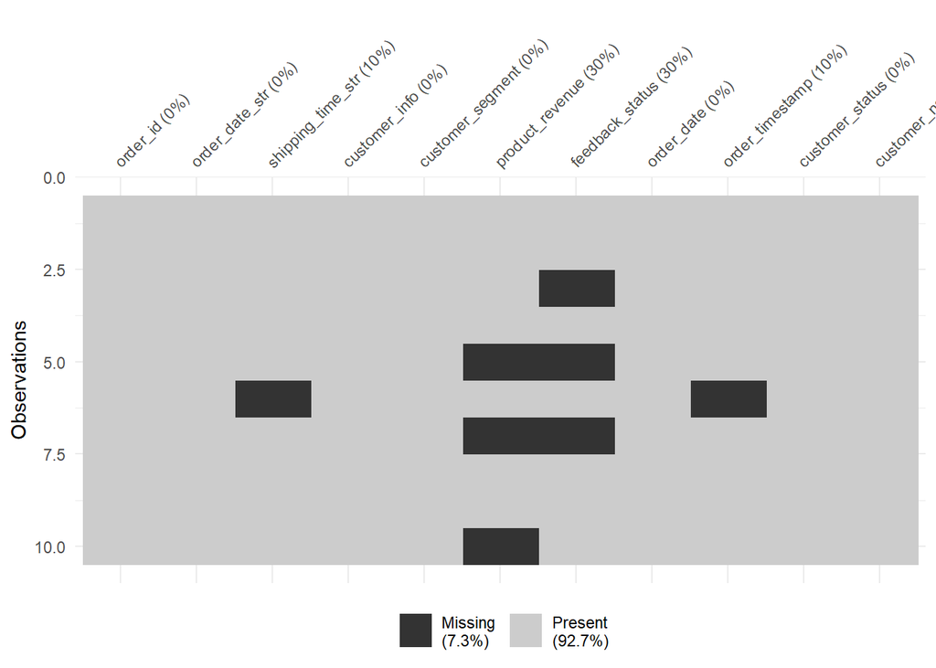

```r
# Your code goes here
# Note: Make sure you've completed Part 3 first to create sales_data_clean
sales_data_conditional <- sales_data_clean %>%
  mutate(
    product_revenue = if_else(
      customer_segment == "Tier 2" & product_revenue < 100,
      NA_real_,
      product_revenue
    )
  )

# Visualize new missing pattern
vis_miss(sales_data_conditional)
```

```r
# Compare before and after
cat("Original missing pattern:\n")
```

```
## Original missing pattern:
```

```r
print(miss_var_summary(sales_data_clean) %>% filter(n_miss > 0))
```

```
## # A tibble: 3 × 3
##   variable          n_miss pct_miss
##   <chr>              <int>    <num>
## 1 feedback_status        3       30
## 2 shipping_time_str      1       10
## 3 order_timestamp        1       10
```

```r
cat("\nAfter introducing conditional missingness:\n")
```

```
##
## After introducing conditional missingness:
```

```r
print(miss_var_summary(sales_data_conditional) %>% filter(n_miss > 0))
```

```
## # A tibble: 4 × 3
##   variable          n_miss pct_miss
##   <chr>              <int>    <num>
## 1 product_revenue        3       30
## 2 feedback_status        3       30
## 3 shipping_time_str      1       10
## 4 order_timestamp        1       10
```

## Challenge 4: Data Quality Checks (5 minutes)

### **Challenge 4A: Revenue Validation**

Check for any unusual values in the `product_revenue` column. Are there any negative values or values that seem unreasonably high? Create a summary of revenue statistics by customer segment.

**Hint:** Use `summary()`, `group_by()`, and `summarise()` to explore the revenue distribution.

```r
# Your code goes here
# Note: Make sure you've completed Part 3 first to create sales_data_clean
cat("Overall revenue summary:\n")
```

```
## Overall revenue summary:
```

```r
print(summary(sales_data_clean$product_revenue))
```

```
##    Min. 1st Qu.  Median    Mean 3rd Qu.    Max.
##  -50.00   81.44  120.37  254.32  290.24 1250.00
```

```r
# Check for problematic values
problematic_values <- sales_data_clean %>%
  filter(product_revenue < 0 | product_revenue > 1000)

cat("\nProblematic revenue values (negative or >$1000):\n")
```

```
##
## Problematic revenue values (negative or >$1000):
```

```r
print(problematic_values %>% select(order_id, customer_name, product_revenue))
```

```
## # A tibble: 2 × 3
##   order_id     customer_name product_revenue
##   <chr>        <chr>                   <dbl>
## 1 ORD-20230505 Mike A                    -50
## 2 ORD-20220818 Emily R                  1250
```

```r
# Revenue statistics by customer segment
cat("\nRevenue statistics by customer segment:\n")
```

```
##
## Revenue statistics by customer segment:
```

```r
sales_data_clean %>%
  group_by(customer_segment) %>%
  summarise(
    count = n(),
    mean_revenue = round(mean(product_revenue, na.rm = TRUE), 2),
    median_revenue = round(median(product_revenue, na.rm = TRUE), 2),
    min_revenue = min(product_revenue, na.rm = TRUE),
    max_revenue = max(product_revenue, na.rm = TRUE),
    .groups = "drop"
  )
```

```
## # A tibble: 2 × 6
##   customer_segment count mean_revenue median_revenue min_revenue max_revenue
##   <chr>            <int>        <dbl>          <dbl>       <dbl>       <dbl>
## 1 Tier 1               6        370.           235.         46.0       1250
## 2 Tier 2               4         80.2           85.1       -50          200.
```

### **Challenge 4B: Date Consistency Check**

Verify that all order dates fall within a reasonable range (e.g., within 2023). Create a logical check to identify any dates that fall outside the expected year.

**Hint:** Use `year()` and logical operators to check date consistency.

```r
# Your code goes here
# Note: Make sure you've completed Part 1 and 3 to have order_date column
date_check <- sales_data_clean %>%
  mutate(
    order_year = year(order_date),
    is_2023 = order_year == 2023
  )

cat("Date consistency check (expected year: 2023):\n")
```

```
## Date consistency check (expected year: 2023):
```

```r
print(date_check %>% count(is_2023, order_year))
```

```
## # A tibble: 3 × 3
##   is_2023 order_year     n
##   <lgl>        <dbl> <int>
## 1 FALSE         2022     1
## 2 FALSE         2024     1
## 3 TRUE          2023     8
```

```r
# Show problematic dates
cat("\nOrders outside of 2023:\n")
```

```
##
## Orders outside of 2023:
```

```r
problematic_dates <- date_check %>%
  filter(order_year != 2023) %>%
  select(order_id, order_date, order_year)

print(problematic_dates)
```

```
## # A tibble: 2 × 3
##   order_id     order_date          order_year
##   <chr>        <dttm>                   <dbl>
## 1 ORD-20240410 2024-04-10 00:00:00       2024
## 2 ORD-20220818 2022-08-18 00:00:00       2022
```

## 🎯 Activity Wrap-up

Congratulations on completing the data cleaning challenge! You have successfully practiced handling three of the most common data wrangling tasks:

1. **Date/Time Manipulation:** Converting messy date strings into usable formats.
2. **String Manipulation:** Extracting and cleaning specific information from text.
3. **Missing Value Handling:** Identifying, standardizing, and imputing missing data.

### **Discussion:**

Once everyone has finished, let’s discuss your findings. Be prepared to answer the following questions:

- Which part of the activity was the most challenging for you?
- What was the most surprising thing you learned about working with messy data?
- If this were a real dataset, what would be your next steps for analysis?
- For those who completed the challenge activities: What additional insights did you gain about the data quality?